# Enunciado

Trabajamos como científicos de datos para una empresa de retail que, debido al cambio en los hábitos de consumo de los clientes, está potenciando ampliamente el servicio de venta online. La empresa quiere realizar un modelo de aprendizaje automático para clasificar a los clientes en función de la probabilidad de generar ingresos al comprar en la web. El objetivo es realizar una serie de acciones específicas para los clientes que es más probable que hagan compras en la web.

Para ello, la empresa ha ido recopilando datos con su herramienta de Google Analytics. Cuenta con datos de sesiones, cada una de ellas de un cliente distinto en un periodo de un año.

# Se pide

Tareas que nos pide la empresa:

- Realización de un análisis de las variables del dataset de Google Analytics como pueden ser histogramas, boxplots, etc. Cualquier otro análisis es bienvenido, siempre explicándolo y con un sentido de negocio.
- Tratamiento de los valores faltantes, outliers, etc., en caso de que los hubiese. Si hay valores con missings, habrá que eliminarlos con el método de Pandas llamado Dropna().a.
- Tratamiento de categóricas, pasándolas a numéricas por medio de dummies, mapeándolas o utilizando un label encoder. Hay que justificar las operaciones que se realizan.
- Si existe alguna variable que se necesite borrar, habrá que borrara y justificarlo.
- Estandariza los datos.
- Dividir los datos en train y en test. Con los datos de train se pretende ajustar modelos con CrossValidation y GridSearch.
- Utilizar un modelo lineal. Entre los modelos lineales están las regresiones logísticas, las regresiones lineales, etc.
- Utilizar un modelo de redes neuronales.
- Utilizar cualquier otro modelo de clasificación.
- Optimizar algún parámetro de cada modelo utilizando CrossValidation y GridSearch, o de la forma que se estime oportuna, siempre justificándolo.
- Elegir el mejor modelo de los tres según la métrica ROC en CrossValidation. Predecir Test y obtener una métrica estimada.
- Umbralizar las probabilidades utilizando el umbral que maximice el área bajo la curva ROC.

# Información de los datos:

El conjunto de datos consta de diez atributos numéricos y ocho categóricos.

- El atributo revenue puede ser usado como la etiqueta de la clase.
- Administrative, administrative duration, informational, informational duration, product related y product related duration representan el número de diferentes tipos de páginas visitadas por el visitante en esa sesión y el tiempo total dedicado a cada una de estas categorías de páginas. Los valores de estas características se derivan de la información del URL de las páginas visitadas por el usuario y se actualizan en tiempo real cuando el usuario realiza una acción, por ejemplo, pasar de una página a otra.
- Las características bounce rate, exit rate y page value representan las métricas medidas por Google Analytics para cada página del sitio de comercio electrónico. El valor de la característica bounce rate de una página web se refiere al porcentaje de visitantes que entran en el sitio desde esa página y luego salen (rebote) sin activar ninguna otra solicitud al servidor de análisis durante esa sesión. El valor de la característica exit rate para una página web específica se calcula como para todas las visitas a la página, el porcentaje que fueron las últimas en la sesión. La función Page Value representa el valor medio de una página web que un usuario ha visitado antes de completar una transacción de comercio electrónico.
- La característica de special day indica la cercanía de la hora de visita del sitio a un día especial específico (por ejemplo, el Día de la Madre, San Valentín) en el que es más probable que las sesiones finalicen con una transacción. El valor de este atributo se determina teniendo en cuenta la dinámica del comercio electrónico, como la duración entre la fecha del pedido y la fecha de entrega. Por ejemplo, para San Valentín, este valor toma un valor distinto de 0 entre el 2 y el 12 de febrero, 0 antes y después de esta fecha a menos que esté cerca de otro día especial, y su valor máximo de 1 el 8 de febrero. El conjunto de datos también incluye el sistema operativo, el navegador, la región, el tipo de tráfico, el tipo de visitante como visitante que regresa o como nuevo visitante, un valor booleano que indica si la fecha de la visita es de fin de semana, y el mes del año.

```python
# Carga de librerías:
from sklearn.model_selection import train_test_split
from sklearn.preprocessing import LabelEncoder, StandardScaler
from sklearn.model_selection import GridSearchCV
from sklearn.linear_model import LogisticRegression
from sklearn.neural_network import MLPClassifier
from sklearn.tree import DecisionTreeClassifier
import sklearn.metrics as metrics
from IPython.core.display import display, HTML
import pandas as pd
import seaborn as sns
import matplotlib.pyplot as plt
import numpy as np
import warnings
warnings.filterwarnings('ignore')
```

# Lectura de los datos

```python
# Lectura de datos
data = pd.read_csv('./online_shoppers_intention.csv', sep=',', index_col=False)
data.head()
```

|  | Administrative | Administrative_Duration | Informational | Informational_Duration | ProductRelated | ProductRelated_Duration | BounceRates | ExitRates | PageValues | SpecialDay | Month | OperatingSystems | Browser | Region | TrafficType | VisitorType | Weekend | Revenue |
| --- | --- | --- | --- | --- | --- | --- | --- | --- | --- | --- | --- | --- | --- | --- | --- | --- | --- | --- |
| 0 | 0.0 | 0.0 | 0.0 | 0.0 | 1.0 | 0.000000 | 0.20 | 0.20 | 0.0 | 0.0 | Feb | 1 | 1 | 1 | 1 | Returning_Visitor | False | False |
| 1 | 0.0 | 0.0 | 0.0 | 0.0 | 2.0 | 64.000000 | 0.00 | 0.10 | 0.0 | 0.0 | Feb | 2 | 2 | 1 | 2 | Returning_Visitor | False | False |
| 2 | 0.0 | -1.0 | 0.0 | -1.0 | 1.0 | -1.000000 | 0.20 | 0.20 | 0.0 | 0.0 | Feb | 4 | 1 | 9 | 3 | Returning_Visitor | False | False |
| 3 | 0.0 | 0.0 | 0.0 | 0.0 | 2.0 | 2.666667 | 0.05 | 0.14 | 0.0 | 0.0 | Feb | 3 | 2 | 2 | 4 | Returning_Visitor | False | False |
| 4 | 0.0 | 0.0 | 0.0 | 0.0 | 10.0 | 627.500000 | 0.02 | 0.05 | 0.0 | 0.0 | Feb | 3 | 3 | 1 | 4 | Returning_Visitor | True | False |

```python
print(u'- El número de filas en el dataset es: {}'.format(data.shape[0]))
print(u'- El número de columnas en el dataset es: {}'.format(data.shape[1]))
print(u'- Los nombres de las variables son: {}'.format(list(data.columns)))
```

[output not shown]

```python
def analyse_data(data):
  data_types = dict(data.dtypes)
  numeric_cols = []
  categoric_cols = []
  for c,t in data_types.items():
    if t == np.float64:
      numeric_cols.append([c, 'Cuantitativa continua', data[c].mean(), data[c].min(), data[c].max(), data[c].median()])
    elif t == np.int64 or pd.Int64Dtype.is_dtype(t):
      numeric_cols.append([c, 'Cuantitativa discreta', data[c].mean(), data[c].min(), data[c].max(), data[c].median()])
    else:
      categoric_cols.append([c, f'Cualitativa', data[c].nunique()])
  n = pd.DataFrame(numeric_cols, columns=['Nombre', 'Tipo de variable', 'Media', 'Mínimo', 'Máximo', 'Mediana'])
  c = pd.DataFrame(categoric_cols, columns=['Nombre', 'Tipo de variable', 'Número de clases'])
  return n, c

numeric_types, categoric_types = analyse_data(data)
print("Finalizado OK")
```

```
Finalizado OK
```

# Preprocesamiento de los datos

### Valores faltantes

```python
data.isnull().sum()
```

```
Administrative             14
Administrative_Duration    14
Informational              14
Informational_Duration     14
ProductRelated             14
ProductRelated_Duration    14
BounceRates                14
ExitRates                  14
PageValues                  0
SpecialDay                  0
Month                       0
OperatingSystems            0
Browser                     0
Region                      0
TrafficType                 0
VisitorType                 0
Weekend                     0
Revenue                     0
dtype: int64
```

```python
print("Eliminando datos nulos:")
print()
data = data.dropna()
```

```
Eliminando datos nulos:
```

```python
print("Número de filas válidas por columna:")
print(data.count().to_string())
```

```
Número de filas válidas por columna:
Administrative             12316
Administrative_Duration    12316
Informational              12316
Informational_Duration     12316
ProductRelated             12316
ProductRelated_Duration    12316
BounceRates                12316
ExitRates                  12316
PageValues                 12316
SpecialDay                 12316
Month                      12316
OperatingSystems           12316
Browser                    12316
Region                     12316
TrafficType                12316
VisitorType                12316
Weekend                    12316
Revenue                    12316
```

### Valores duplicados

```python
print(f"Número de filas: {data.shape[0]}")
print(f"Número de columnas: {data.shape[1]}")
print()
print("Eliminando filas con valores duplicados...")
data = data.drop_duplicates()
print()
print(f"Número de filas: {data.shape[0]}")
print(f"Número de columnas: {data.shape[1]}")
```

```
Número de filas: 12316
Número de columnas: 18

Eliminando filas con valores duplicados...

Número de filas: 12199
Número de columnas: 18
```

### Valores atípicos

Analizamos los valores atípicos de las variables cuantitativas para descartarlos posteriormente.

```python
numeric_data = data.select_dtypes(include=['float', 'int'])
numeric_data.columns
```

```
Index(['Administrative', 'Administrative_Duration', 'Informational',
       'Informational_Duration', 'ProductRelated', 'ProductRelated_Duration',
       'BounceRates', 'ExitRates', 'PageValues', 'SpecialDay',
       'OperatingSystems', 'Browser', 'Region', 'TrafficType'],
      dtype='object')
```

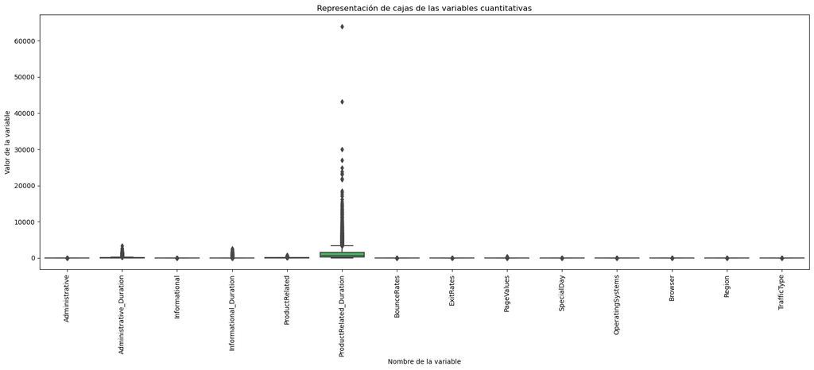

```python
plt.figure(figsize=(21,7))
ax = sns.boxplot(data=numeric_data)
ax.set_xticklabels(ax.get_xticklabels(), rotation= 90)
plt.title(u'Representación de cajas de las variables cuantitativas')
plt.ylabel(u'Valor de la variable')
_ = plt.xlabel(u'Nombre de la variable')
```

Con el siguiente código eliminamos los valores atípicos indicando los nombres de las columnas en el vector columns_with_outliers.

```
Número de filas (con valores atípicos): 12199
Eliminando valores atípicos...
Número de filas (sin valores atípicos): 5634

Datos Cuantitativos:
                 Nombre      Tipo de variable      Media  Mínimo      Máximo    Mediana
         Administrative Cuantitativa continua   1.326056     0.0   10.000000   0.000000
Administrative_Duration Cuantitativa continua  31.347876     0.0  236.000000   0.000000
          Informational Cuantitativa continua   0.000000     0.0    0.000000   0.000000
 Informational_Duration Cuantitativa continua   0.000000     0.0    0.000000   0.000000
         ProductRelated Cuantitativa continua  19.246716     0.0   83.000000  14.000000
ProductRelated_Duration Cuantitativa continua 663.830219     0.0 3401.050687 431.500000
            BounceRates Cuantitativa continua   0.007039     0.0    0.041667   0.000000
              ExitRates Cuantitativa continua   0.030282     0.0    0.095238   0.026316
             PageValues Cuantitativa continua   0.000000     0.0    0.000000   0.000000
             SpecialDay Cuantitativa continua   0.063756     0.0    1.000000   0.000000
       OperatingSystems Cuantitativa discreta   2.119453     1.0    8.000000   2.000000
                Browser Cuantitativa discreta   2.390309     1.0   13.000000   2.000000
                 Region Cuantitativa discreta   3.217075     1.0    9.000000   3.000000
            TrafficType Cuantitativa discreta   4.027689     1.0   20.000000   2.000000
```

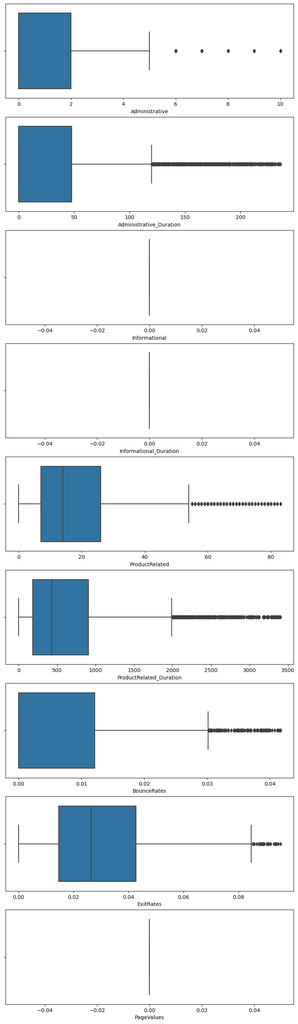

```python
columns_with_outliers = ['Administrative', 'Administrative_Duration', 'Informational', 'Informational_Duration', 'ProductRelated', 'ProductRelated_Duration',
'BounceRates', 'ExitRates', 'PageValues']
print(f"Número de filas (con valores atípicos): {data.shape[0]}")
print("Eliminando valores atípicos...")
Q1 = data[columns_with_outliers].quantile(0.25)
Q3 = data[columns_with_outliers].quantile(0.75)
IQR = Q3 - Q1
data2 = data[~((data[columns_with_outliers] < (Q1 - 1.5 * IQR)) | (data[columns_with_outliers] > (Q3 + 1.5 * IQR))).any(axis=1)]
print(f"Número de filas (sin valores atípicos): {data2.shape[0]}")

# Assuming the function `analyse_data()` is defined elsewhere
numeric_types, categoric_types = analyse_data(data2)
print()
print("Datos Cuantitativos:")
print(numeric_types.to_string(index=False))
print()

fig, axs = plt.subplots(figsize=(10, 35), nrows=9)
sns.boxplot(x=data2['Administrative'], ax=axs[0])
sns.boxplot(x=data2['Administrative_Duration'], ax=axs[1])
sns.boxplot(x=data2['Informational'], ax=axs[2])
sns.boxplot(x=data2['Informational_Duration'], ax=axs[3])
sns.boxplot(x=data2['ProductRelated'], ax=axs[4])
sns.boxplot(x=data2['ProductRelated_Duration'], ax=axs[5])
sns.boxplot(x=data2['BounceRates'], ax=axs[6])
sns.boxplot(x=data2['ExitRates'], ax=axs[7])
sns.boxplot(x=data2['PageValues'], ax=axs[8])

plt.show()
```

Podemos observar que las columnas 'Informational_Duration', 'Informational' y 'PageValues' solo nos dan valores atípicos, por lo tanto, estas columnas no nos serviran para nuestro análisis.

```python
data = data.drop(columns=['Informational', 'Informational_Duration', 'PageValues'])
numeric_data = numeric_data.drop(columns=['Informational', 'Informational_Duration', 'PageValues'])
data.columns
```

```
Index(['Administrative', 'Administrative_Duration', 'ProductRelated',
       'ProductRelated_Duration', 'BounceRates', 'ExitRates', 'SpecialDay',
       'Month', 'OperatingSystems', 'Browser', 'Region', 'TrafficType',
       'VisitorType', 'Weekend', 'Revenue'],
      dtype='object')
```

# Análisis univariante

### Variables cualitativas

```python
print(categoric_types.to_string(index=False))
```

```
     Nombre Tipo de variable  Número de clases
      Month      Cualitativa                10
VisitorType      Cualitativa                 3
    Weekend      Cualitativa                 2
    Revenue      Cualitativa                 2
```

Visualizamos las variables cualitativas para conocer su distribución de valores:

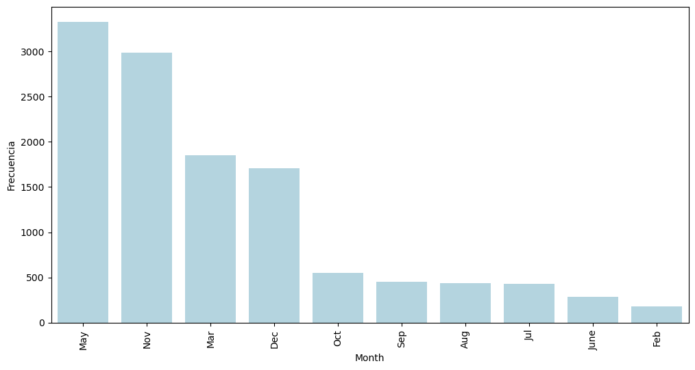

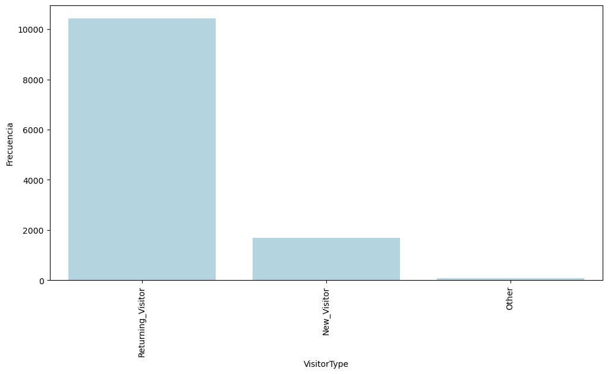

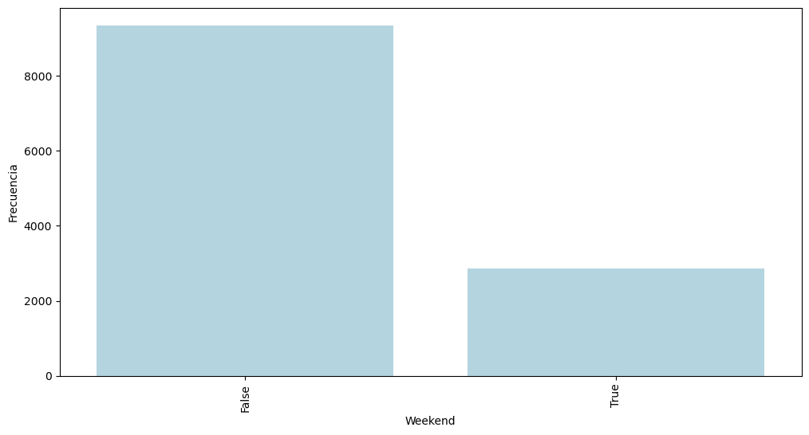

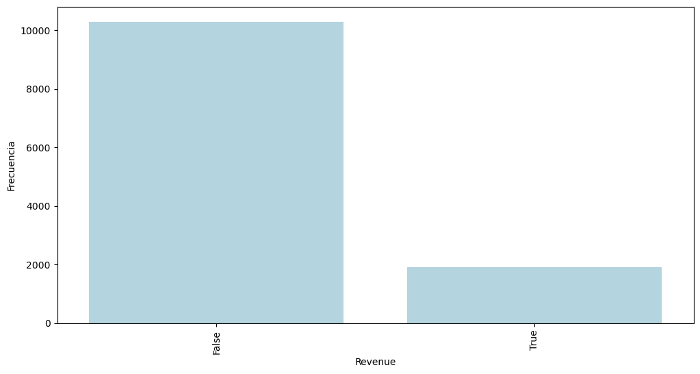

```python
for i in categoric_types.index:
      if categoric_types['Nombre'][i]:
            column = categoric_types['Nombre'][i]
            fig, ax = plt.subplots(figsize=(12,6))
            chart = sns.countplot(data=data, x=column, color='lightblue', order = data[column].value_counts().index)
            chart.set_xticklabels(chart.get_xticklabels(), rotation=90)
            chart.set_ylabel('Frecuencia')
            plt.show()
```

### Variables cuantitativas

Procedamos de manera análoga con las variables cuantitativas y vemos sus estadísticos básicos:

```python
print(numeric_types.to_string(index=False))
```

```
                 Nombre      Tipo de variable      Media  Mínimo      Máximo    Mediana
         Administrative Cuantitativa continua   1.326056     0.0   10.000000   0.000000
Administrative_Duration Cuantitativa continua  31.347876     0.0  236.000000   0.000000
          Informational Cuantitativa continua   0.000000     0.0    0.000000   0.000000
 Informational_Duration Cuantitativa continua   0.000000     0.0    0.000000   0.000000
         ProductRelated Cuantitativa continua  19.246716     0.0   83.000000  14.000000
ProductRelated_Duration Cuantitativa continua 663.830219     0.0 3401.050687 431.500000
            BounceRates Cuantitativa continua   0.007039     0.0    0.041667   0.000000
              ExitRates Cuantitativa continua   0.030282     0.0    0.095238   0.026316
             PageValues Cuantitativa continua   0.000000     0.0    0.000000   0.000000
             SpecialDay Cuantitativa continua   0.063756     0.0    1.000000   0.000000
       OperatingSystems Cuantitativa discreta   2.119453     1.0    8.000000   2.000000
                Browser Cuantitativa discreta   2.390309     1.0   13.000000   2.000000
                 Region Cuantitativa discreta   3.217075     1.0    9.000000   3.000000
            TrafficType Cuantitativa discreta   4.027689     1.0   20.000000   2.000000
```

```python
numeric_types = numeric_types[~numeric_types['Nombre'].isin(['Informational', 'Informational_Duration', 'PageValues'])]
```

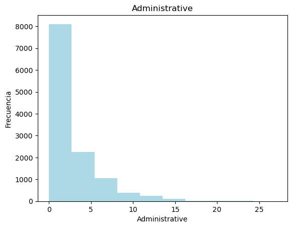

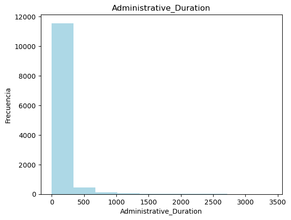

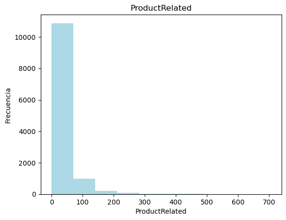

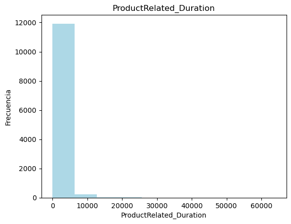

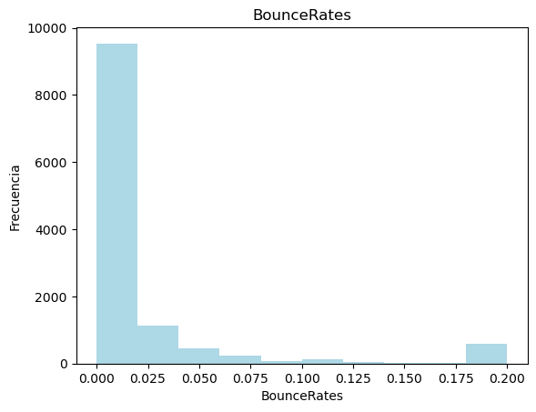

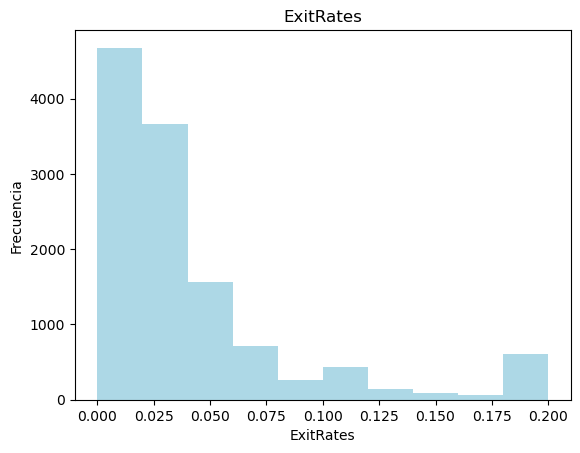

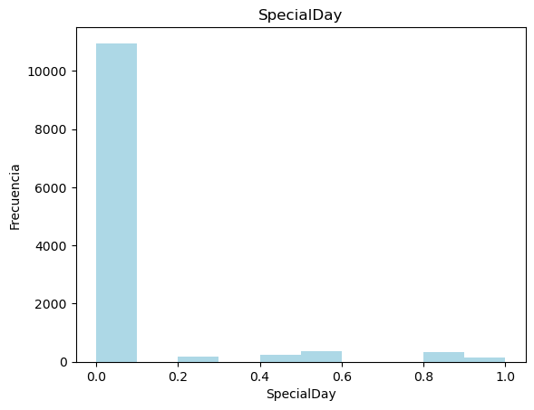

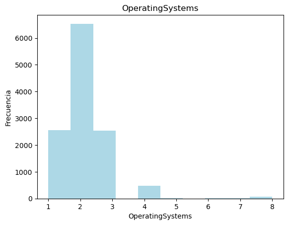

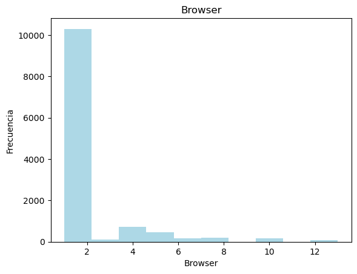

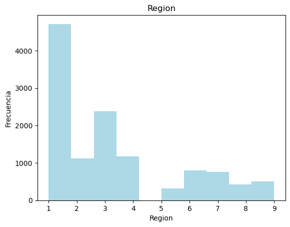

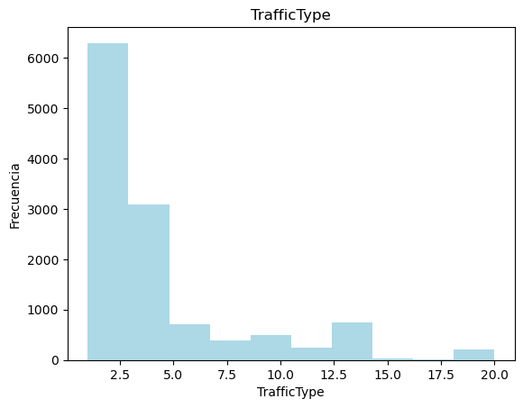

```python
for i in numeric_types.index:
    column = numeric_types['Nombre'][i]
    plt.hist(data[column], color='lightblue')
    plt.xlabel(column)
    plt.ylabel('Frecuencia')
    plt.title(column)
    plt.show()
```

# Análisis bivariante

Ahora, vamos a realizar el análisis de cada variable frente a la variable objetivo que en este caso es Revenue.

### Variables cualitativas vs. Revenue

Para conocer el comportamiento de las variables cualitativas frente a la variable objetivo vamos a utilizar el BarPlot.

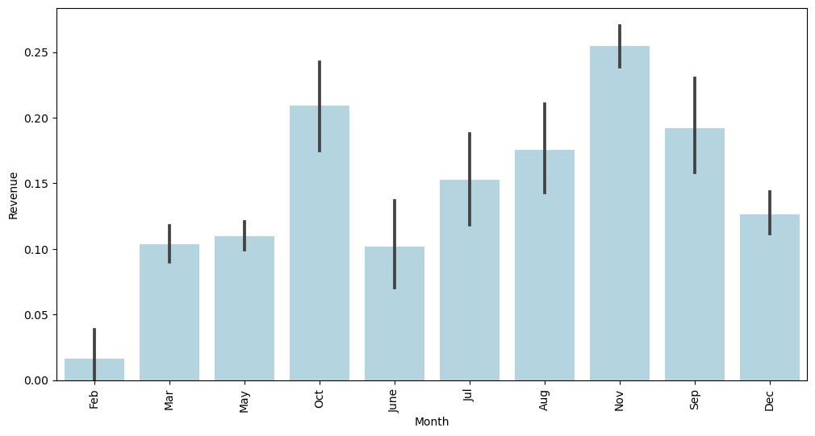

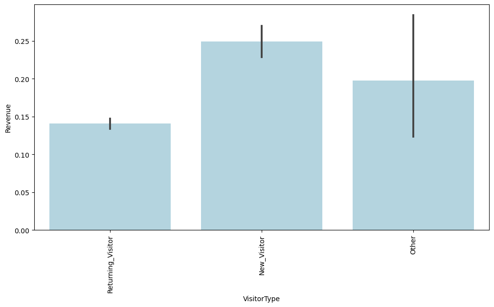

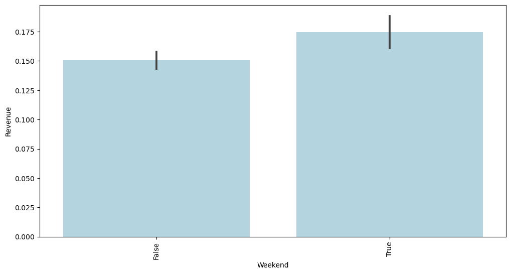

```python
for i in categoric_types.index:
       if categoric_types['Nombre'][i] != 'Revenue':
            x_axis = categoric_types['Nombre'][i]
            y_axis = 'Revenue'
            fig, ax = plt.subplots(figsize=(12,6))
            chart = sns.barplot(data=data, x=x_axis, y=y_axis, color='lightblue')
            chart.set_xticklabels(chart.get_xticklabels(), rotation=90)
            plt.show()
```

### Variables cuantitativas vs. Revenue

Para conocer el comportamiento de las variables cuantitativas frente a la variable objetivo vamos a utilizar el BoxPlot.

```python
numeric_types
```

|  | Nombre | Tipo de variable | Media | Mínimo | Máximo | Mediana |
| --- | --- | --- | --- | --- | --- | --- |
| 0 | Administrative | Cuantitativa continua | 1.326056 | 0.0 | 10.000000 | 0.000000 |
| 1 | Administrative_Duration | Cuantitativa continua | 31.347876 | 0.0 | 236.000000 | 0.000000 |
| 4 | ProductRelated | Cuantitativa continua | 19.246716 | 0.0 | 83.000000 | 14.000000 |
| 5 | ProductRelated_Duration | Cuantitativa continua | 663.830219 | 0.0 | 3401.050687 | 431.500000 |
| 6 | BounceRates | Cuantitativa continua | 0.007039 | 0.0 | 0.041667 | 0.000000 |
| 7 | ExitRates | Cuantitativa continua | 0.030282 | 0.0 | 0.095238 | 0.026316 |
| 9 | SpecialDay | Cuantitativa continua | 0.063756 | 0.0 | 1.000000 | 0.000000 |
| 10 | OperatingSystems | Cuantitativa discreta | 2.119453 | 1.0 | 8.000000 | 2.000000 |
| 11 | Browser | Cuantitativa discreta | 2.390309 | 1.0 | 13.000000 | 2.000000 |
| 12 | Region | Cuantitativa discreta | 3.217075 | 1.0 | 9.000000 | 3.000000 |
| 13 | TrafficType | Cuantitativa discreta | 4.027689 | 1.0 | 20.000000 | 2.000000 |

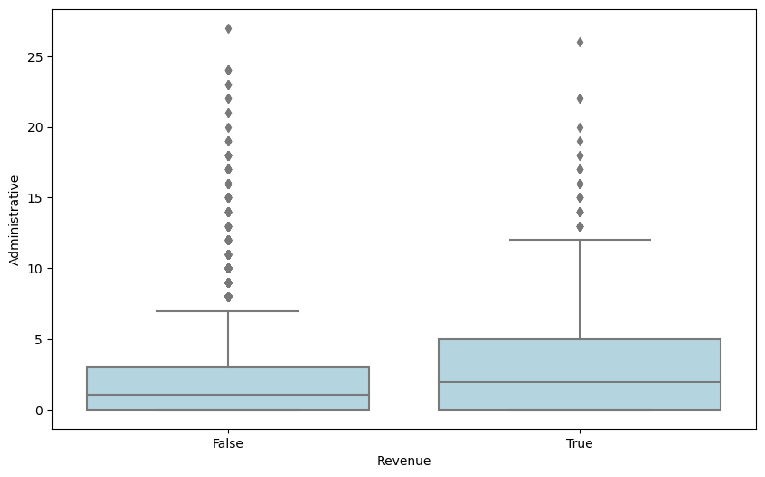

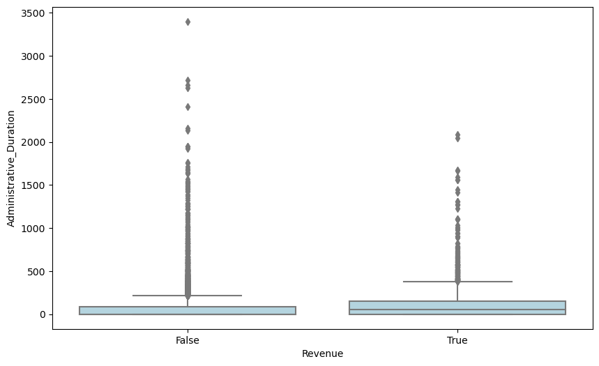

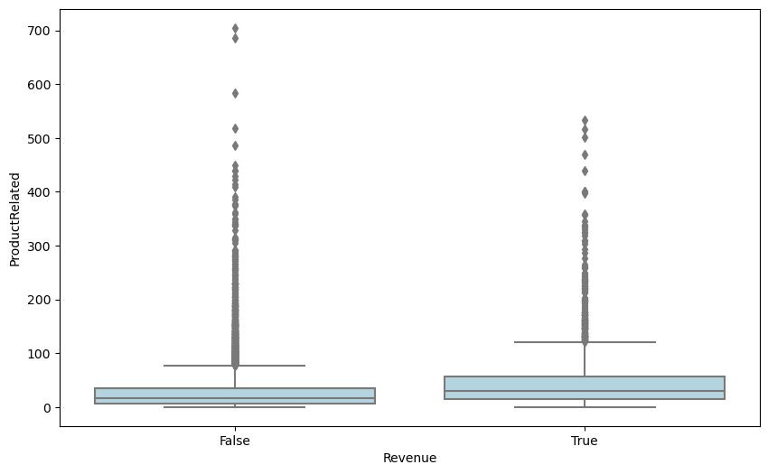

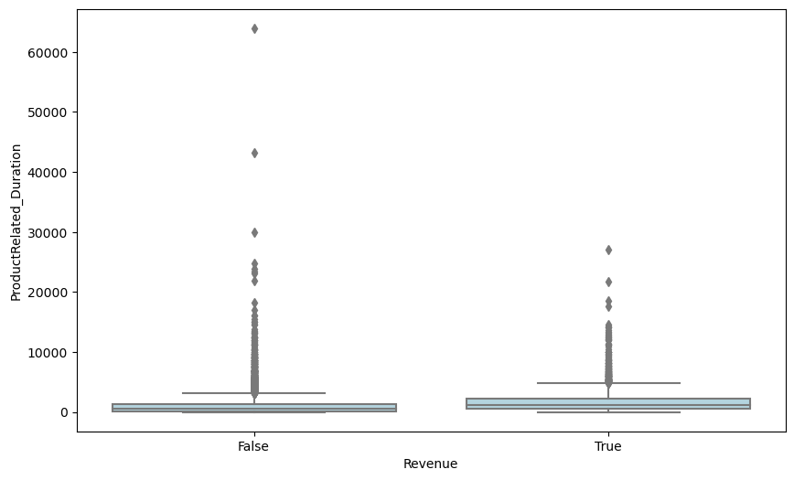

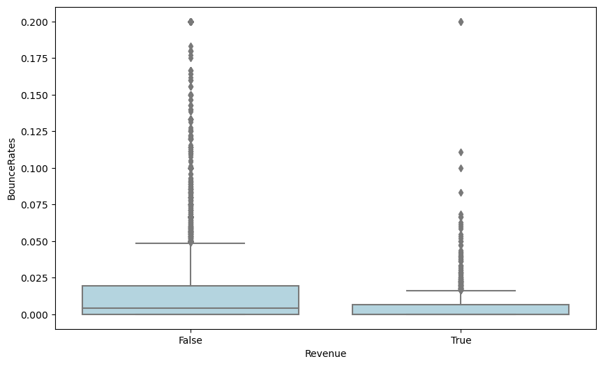

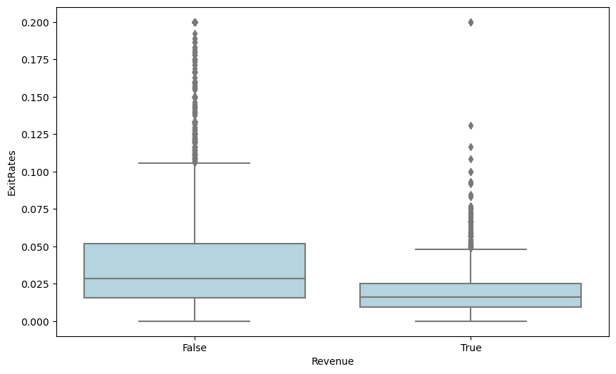

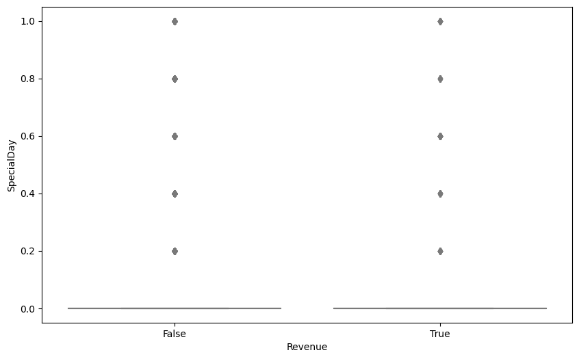

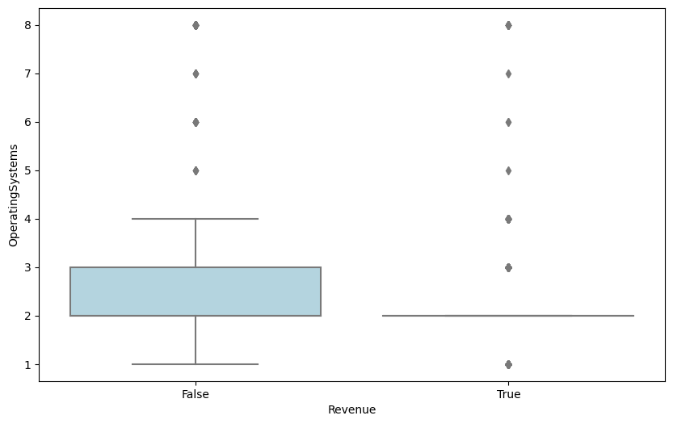

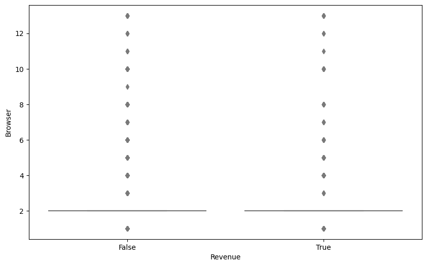

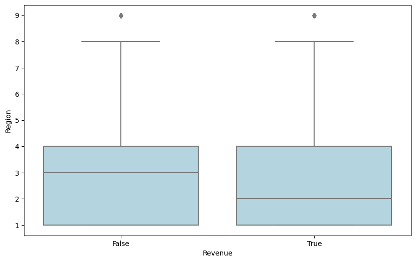

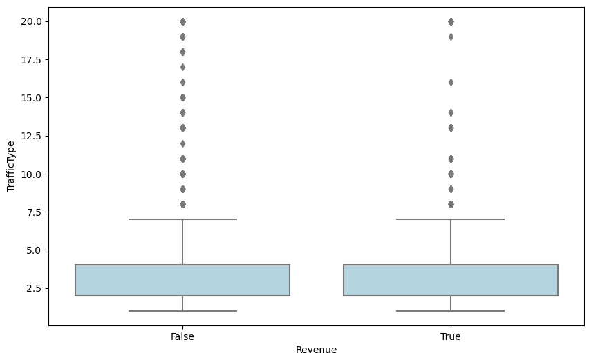

```python
for i in numeric_types.index:
      y_axis = numeric_types['Nombre'][i]
      x_axis = 'Revenue'
      fig, ax = plt.subplots(figsize=(10, 6))
      chart = sns.boxplot(data=data, x=x_axis, y=y_axis, color='lightblue')
      plt.show()
```